# Part II - Student's Perception of Control and Their Learning Behaviour

## by Daniel Oliveira

## Investigation Overview

In this investigation I wanted to understand how students' perception of control of math outcomes would influence thoughts and behaviour regarding his/her learning.

I've learned that when the perception of control of their outcomes is higher, it's more frequent to see behaviour and thoughts torwards school and learning engagement. But when it comes to "blaming" the teacher for the student's effort in learning it seems to have the opposite effect.

## Dataset Overview

This dataset contains answers regarding a survey of around 15 year-old students' skills and knowledge, with around 510,000 students in 65 economies. Due to data wrangling, only answers from 427386 students were used, all of them born in the country of the survey.

## Distribution of Student's Perception of Control of Outcomes

Most students say that their outcomes in mathematics is entirely up to them. In fact, around 85% agree with this. But when asked if their teachers would make a difference regarding their own effort in learning, the percentage of students who don't agree with this is around 60%.

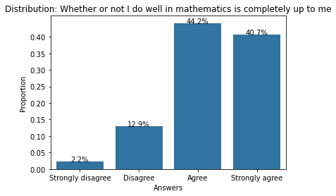

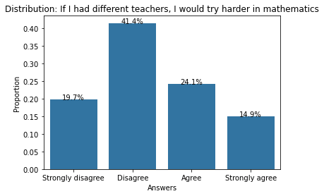

## Distribution of Students' Math Work Ethic

There are more students that agree that they study hard for math quizzes, but more than 40% don't say the same, so it's almost even.

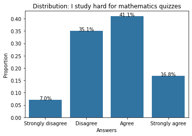

## Perception of Control of Outcomes (General) vs Math Work Ethic

Students that believe it's up to them to get good results in mathematics tend to report more that they study hard for their quizzes.

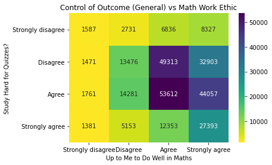

## Perception of Control of Outcomes (Teacher Role) vs Math Work Ethic

But students that report NOT studying hard for quizzes more frequently say that changing teachers wouldn't make a difference in their effort.

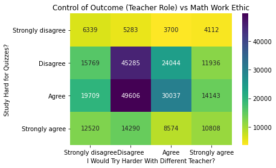

With the teacher's role seemingly very important, we noted that truancy would only make a difference on student's math work ethic when the perception of this role by the teacher (in terms of their own outcomes) remains the same. With that, we can see that student's that report not studying hard for math quizzes have also skipped more classes.

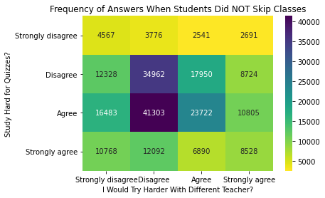

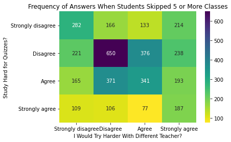